# Mouse and Rat Glioblastoma Models

Stefan Loska

March 14, 2017

```r
library(oligo)
library(Biobase)
library(AnnotationDbi)
```

# Introduction

The aim of this analysis was to compare gene expression profile observed in rat (C6) and mouse (GL) glioblastoma model to those observed in human to determine which of these two models better mimics the human landscape.

# Downloading the data

```r
# gene homology data
download.file("ftp://ftp.ncbi.nih.gov/pub/HomoloGene/build68/homologene.data", "homologene.data")

# GEO Data: GSE12657, Expression data from human glioma samples
download.file("ftp://ftp.ncbi.nlm.nih.gov/geo/series/GSE12nnn/GSE12657/matrix/GSE12657_series_matrix.txt.gz",
              "GSE12657_series_matrix.txt.gz")

# Verhaak data: Verhaak RG, Hoadley KA, Purdom E, et al: Integrated genomic analysis identifies clinically relevant subtypes of glioblastoma characterized by abnormalities in PDGFRA, IDH1, EGFR, and NF1. Cancer Cell. 2010 Jan 19;17(1):98-110
download.file("https://tcga-data.nci.nih.gov/docs/publications/gbm_exp/TCGA_unified_CORE_ClaNC840.txt", "Verhaak.tsv")
download.file("https://tcga-data.nci.nih.gov/docs/publications/gbm_exp/ClaNC840_centroids.xls", "ClaNC840_centroids.xls")
```

# Preparing microarray data

## Reading data

Read data from cel files and probe annotation file.

```r
read_cel <- function(data_dir, s_info, skip = NULL){
  # get sample meta data
  tab <- read.delim(paste(data_dir, s_info, sep = "/"), colClasses = c("character", "factor", "character"))
  rownames(tab) <- tab$filename
  # check sample_info vs. cel files
  if (! setequal(tab$filename, list.celfiles(data_dir))) stop("sample info file doesn't fit available cel files")

  # skip what is meant to skip
  tab <- tab[!rownames(tab) %in% skip,]

  # get microarray signal
  ab <- read.celfiles(filenames = paste(data_dir, tab$filename, sep = "/"), phenoData = AnnotatedDataFrame(tab))
  colnames(ab) <- tab$id
  ab
}
```

## Preprocessing

RMA

```r
rma_core <- function(ab){
  R <- oligo::rma(ab, target = "core")
  R
}
```

## Annotation

Get annotation and remove probes mapping to more than one gene.

```r
annotate <- function(R, annot){
  # choose columns for feature data
  fd <- select(annot, keys = rownames(R), keytype = "PROBEID", columns = c("ENTREZID", "SYMBOL", "GENENAME"))

  fd <- fd[!is.na(fd$ENTREZID),]

  freq <- table(fd$PROBEID)
  dambg <- names(freq)[freq == 1]
  fd <- fd[fd$PROBEID %in% dambg, ]
  rownames(fd) <- fd$PROBEID

  R <- R[rownames(fd)]
  fData(R) <- fd

  R
}
```

Pick up one probe for each gene. This will be the probe with the highest variance among samples.

```r
dedegen <- function(R){
  # keep only one probeset per gene; this will be the one with highest variance
  sel <- tapply(seq_along(fData(R)$ENTREZID), fData(R)$ENTREZID, c)

  sel <- tapply(seq_along(fData(R)$ENTREZID), fData(R)$ENTREZID, function(x){
    if (length(x) == 1) x else{
      vars <- apply(exprs(R)[x,], 1, var, na.rm = T)
      x[which.max(vars)]
    }
  })

  sel <- as.vector(sel)

  R <- R[sel,]
  R
}
```

Convert to human.

```r
to_human <- function(R, hom, taxid){
  # human to human just adds extra column in fData and changes rownames
  if (taxid == "9606") {
    fData(R)$HUMENTREZID <- fData(R)$ENTREZID
    rownames(R) <- fData(R)$HUMENTREZID
    return(R)
  }

  # restric to human and taxid
  hom <- hom[hom$tax %in% c("9606", taxid),]

  # remove disambiguities (and no pair), i.e. for each id need exactly one human and one taxid gene
  sel <- tapply(hom$tax, hom$id, function(x){
    length(x) == 2 & length(unique(x)) == 2
  })
  sel <- names(sel)[sel]
  hom <- hom[hom$id %in% sel,]

  # convert fData
  ids <- hom$id[match(fData(R)$ENTREZID, hom$entrez)]
  ens <- hom$entrez[match(ids, hom$id)]

  fData(R)$HUMENTREZID <- ens
  R <- R[!is.na(fData(R)$HUMENTREZID),]
  rownames(R) <- fData(R)$HUMENTREZID

  R
}
```

## Get expression

```r
get_exprs <- function(data_dir, s_info, skip = NULL, annot, hom, taxid){
  ab <- read_cel(data_dir, s_info, skip)
  R <- rma_core(ab)
  R <- annotate(R, annot)
  R <- dedegen(R)
  R <- to_human(R, hom, taxid)
  R
}
```

## Execute on data

```r
hom <- read.delim("homologene.data", header = F,
                  colClasses = c("character", "character", "character", "NULL", "NULL", "NULL"),
                  col.names = c("id", "tax", "entrez", "NULL", "NULL", "NULL"))
```

```r
Rat <- get_exprs(data_dir = "Rat_data",
                 s_info = "sample_info.txt",
                 annot = ragene21sttranscriptcluster.db::ragene21sttranscriptcluster.db,
                 hom = hom,
                 taxid = "10116")
```

```
## Platform design info loaded.
```

```
## Reading in : Rat_data/CTRL_1.ga.cel
## Reading in : Rat_data/CTRL_2.ga.cel
## Reading in : Rat_data/CTRL_3.ga.cel
## Reading in : Rat_data/CTRL_4.ga.cel
## Reading in : Rat_data/C6_1.ga.cel
## Reading in : Rat_data/C6_2.ga.cel
## Reading in : Rat_data/C6_4.ga.cel
## Reading in : Rat_data/C6_5.ga.cel
```

```
## Background correcting
## Normalizing
## Calculating Expression
```

```r
Mouse <- get_exprs(data_dir = "Mouse_data",
          s_info = "sample_info.txt",
          annot = mogene21sttranscriptcluster.db::mogene21sttranscriptcluster.db,
          hom = hom,
          taxid = "10090")
```

```
## Platform design info loaded.
```

```
## Reading in : Mouse_data/CTRL_1.ga.cel
## Reading in : Mouse_data/CTRL_2.ga.cel
## Reading in : Mouse_data/CTRL_3.ga.cel
## Reading in : Mouse_data/CTRL_4.ga.cel
## Reading in : Mouse_data/GL_1.ga.cel
## Reading in : Mouse_data/GL_2.ga.cel
## Reading in : Mouse_data/GL_3.ga.cel
## Reading in : Mouse_data/GL_4.ga.cel
```

```
## Background correcting
## Normalizing
## Calculating Expression
```

## PCA

```r
pca <- function(R, lbs = pData(R)$id){
  # svd
  e <- sweep(exprs(R), 1, rowMeans(exprs(R)))
  s <- svd(e)

  # plot
  pars <- par(no.readonly = T)
  on.exit(par(pars))
  par(pty = "s")
  # calcuklate variance percentage
  labs <- s$d^2
  labs <- round(labs[1:2]/sum(labs)*100, 0)
  labs <- paste(c("PC1: ", "PC2: "), labs, "%", sep = "")
  # draw
  plot(s$v[, 1:2], xlab = labs[1], ylab = labs[2], axes = F, pch = 16, col = as.numeric(pData(R)$class) + 1)
  box()
  abline(h = 0, v = 0, lty = 3)
  text(s$v[, 1], s$v[, 2], lbs, pos = 1)

  invisible(s)
}
```

Plotting PCA:

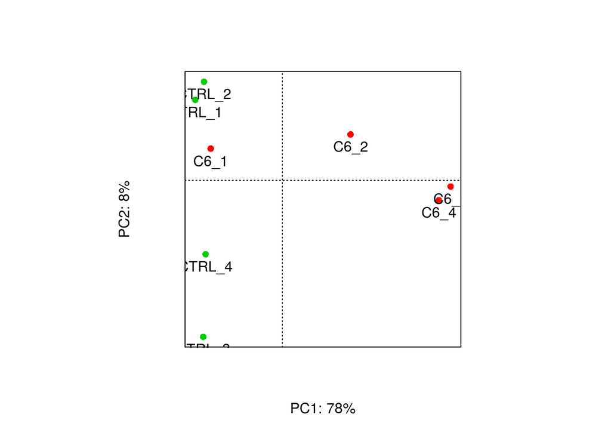

```r
pca(Rat)
```

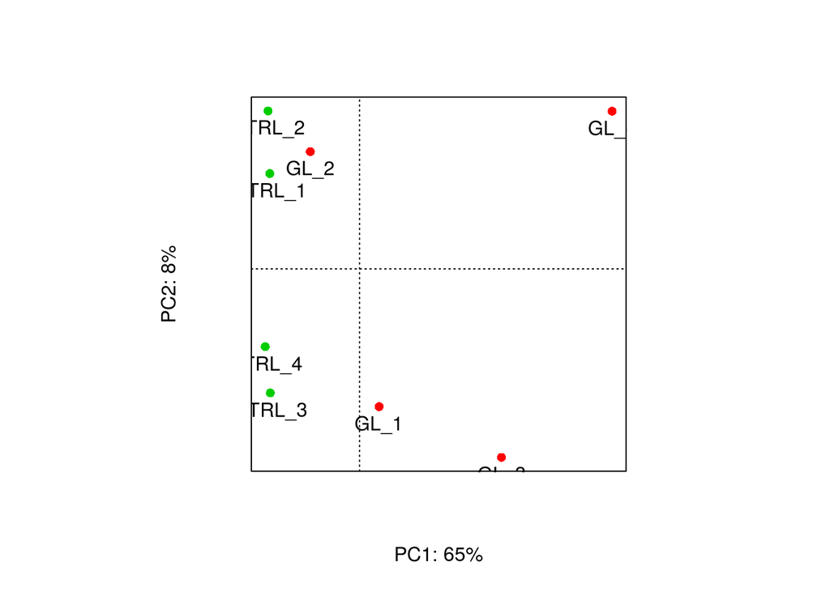

```r
pca(Mouse)
```

## Removing outliers

```r
Rat <- get_exprs(data_dir = "Rat_data",
          s_info = "sample_info.txt",
          skip = "C6_1.ga.cel",
          annot = ragene21sttranscriptcluster.db::ragene21sttranscriptcluster.db,
          hom = hom,
          taxid = "10116")
```

```
## Platform design info loaded.
```

```
## Reading in : Rat_data/CTRL_1.ga.cel
## Reading in : Rat_data/CTRL_2.ga.cel
## Reading in : Rat_data/CTRL_3.ga.cel
## Reading in : Rat_data/CTRL_4.ga.cel
## Reading in : Rat_data/C6_2.ga.cel
## Reading in : Rat_data/C6_4.ga.cel
## Reading in : Rat_data/C6_5.ga.cel
```

```
## Background correcting
## Normalizing
## Calculating Expression
```

PCA after removing outliers:

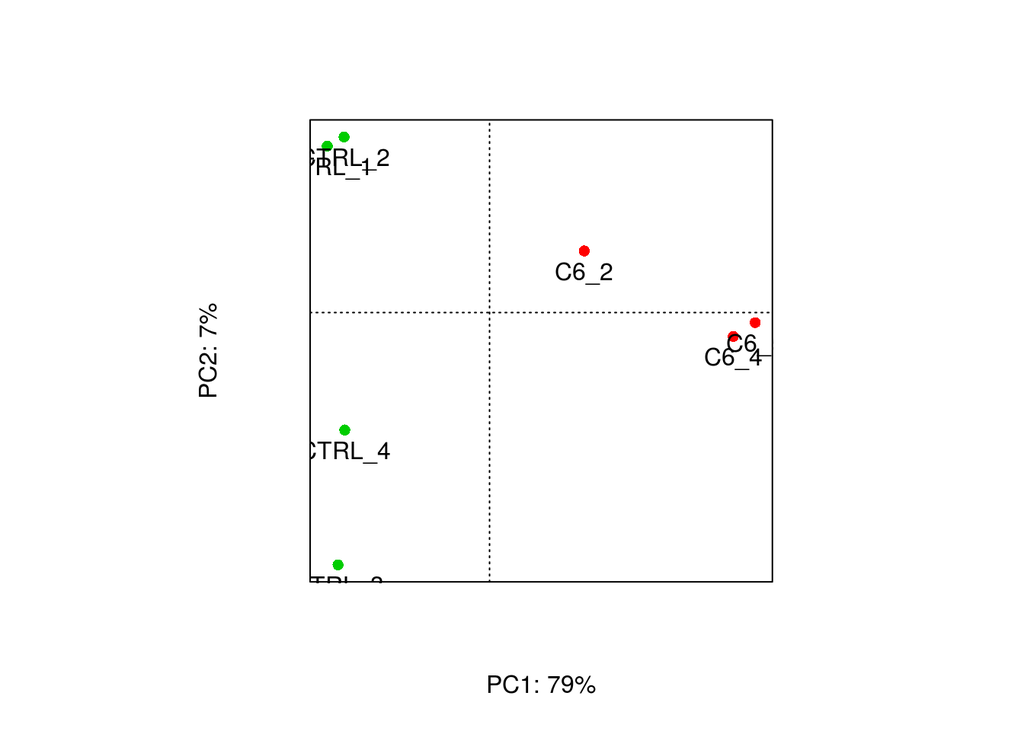

```r
pca(Rat)
```

# Getting GEO data

Dataset GSE12657 titled “Expression data from human glioma samples” was obtained from GEO database.

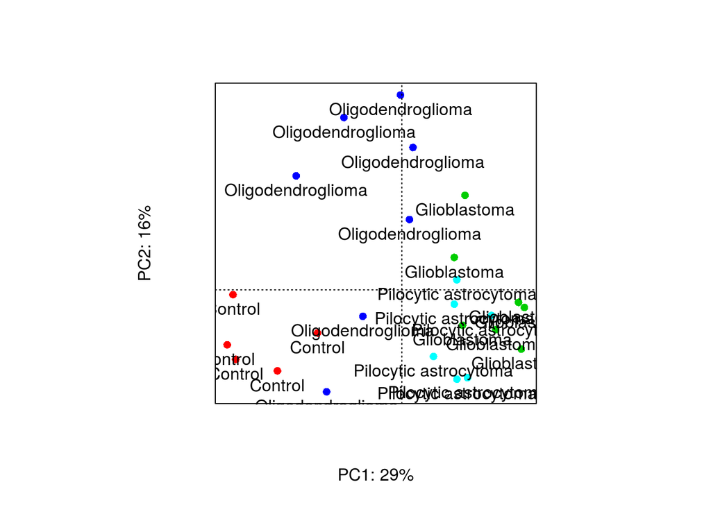

```r
read_geo <- function(geo_file){
  tab <- readLines(geo_file)
  meta <- grepl("^!|^$", tab)

  pd <- grep("^!Sample_characteristics|^\"ID_REF\"", tab, value = T)
  pd <- gsub("\"", "", pd)
  pd <- strsplit(pd , "\t")
  pd <- do.call(cbind, pd)
  pd <- pd[-1, ]
  pd <- data.frame(class = factor(pd[, 1]), id = pd[, 2], stringsAsFactors = F)
  rownames(pd) <- pd$id

  ge <- tab[!meta]
  ge <- gsub("\"", "", ge)
  ge <- strsplit(ge , "\t")
  ge <- do.call(rbind, ge)
  colnames(ge) <- ge[1, ]
  rownames(ge) <- ge[, 1]
  ge <- ge[-1, -1]
  mode(ge) <- "numeric"
  ge <- log2(ge)

  G <- ExpressionSet(ge, AnnotatedDataFrame(pd))

  G
}

build_GEO <- function(geo_file, annot, hom, taxid){
  G <- read_geo(geo_file)
  G <- annotate(G, annot)
  G <- dedegen(G)
  G <- to_human(G, hom, taxid)
  G
}


G <- build_GEO("GSE12657_series_matrix.txt.gz", hgu95av2.db::hgu95av2.db, hom, "9606")
pca(G, lbs = pData(G)$class)
```

# Getting Verhaak data

These data come from:

Verhaak RG, Hoadley KA, Purdom E, et al

Integrated genomic analysis identifies clinically relevant subtypes of glioblastoma characterized by abnormalities in PDGFRA, IDH1, EGFR, and NF1.

Cancer Cell. 2010 Jan 19;17(1):98-110

## Expression data

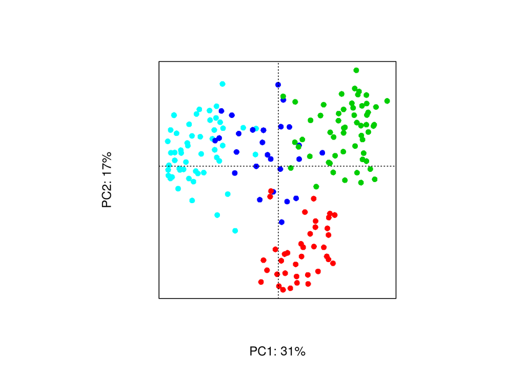

```r
read_ver <- function(ver_file){
  # pheno data
  pd <- read.delim(ver_file, header = F, nrow = 2)
  pd <- t(pd[, -(1:2)])
  pd <- data.frame(class = (factor(pd[,2])), id = pd[,1], stringsAsFactors = F)
  rownames(pd) <- pd$id

  # gene expression
  ge <- read.delim("Verhaak.tsv", header = F, skip = 2, row.names = 1, colClasses = c(NA, "NULL", rep("numeric", nrow(pd))))
  colnames(ge) <- pd$id
  ge <- data.matrix(ge)

  # feature data
  fd <- select(org.Hs.eg.db::org.Hs.eg.db, rownames(ge), keys = rownames(ge), keytype = "ALIAS", columns = c("ENTREZID", "SYMBOL", "GENENAME"))

  # pick up gene symbols/aliases that can be translated to entrez id unambigiously
  da <- table(fd$ALIAS)
  da <- names(da[da == 1]) # disambigous aliases
  de <- table(fd$ENTREZID)
  de <- names(de[de == 1]) # disambigous entrez ids
  fd <- fd[fd$ALIAS %in% da & fd$ENTREZID %in% de,]

  fd$HUMENTREZID <- fd$ENTREZID
  rownames(fd) <- fd$HUMENTREZID

  # limit gene expression to new gene set
  all(fd$ALIAS %in% rownames(ge))
  ge <- ge[fd$ALIAS,]
  rownames(ge) <- rownames(fd)

  # create eSet
  V <- ExpressionSet(ge, AnnotatedDataFrame(pd), AnnotatedDataFrame(fd))
  V
}

V <- read_ver("Verhaak.tsv")
pca(V, lbs = c())
```

## Centroids

```r
get_ces <- function(V, ces_file){
  sel <- sapply(levels(pData(V)$class), function (x){
    which(pData(V)$class == x)[1]
  })

  V_ce <- V[,sel]
  colnames(V_ce) <- levels(pData(V)$class)
  pData(V_ce) <- pData(V_ce)[, colnames(pData(V_ce)) != "id", drop = F]

  ces <- gdata::read.xls(ces_file, header = T, row.names = 1,  stringsAsFactors = F, skip = 2, colClasses = c(NA, "NULL", rep(NA, 4)))
  ces <- ces[fData(V)$ALIAS, ]
  rownames(ces) <- rownames(fData(V))
  ces <- ces[,colnames(V_ce)]
  exprs(V_ce) <- data.matrix(ces)

  V_ce
}

V_ce <- get_ces(V, "ClaNC840_centroids.xls")
```

# Clustering

## Data modification

```r
get_DE <- function(R, ctrl = "CTRL"){
  base <- rowMeans(exprs(R)[, pData(R)$class == ctrl])
  exprs(R) <- sweep(exprs(R), 1, base)
  R#[, pData(R)$class != ctrl]
}

z_score <- function(R){
  exprs(R) <- sweep(exprs(R), 1, rowMeans(exprs(R)))
  exprs(R) <- sweep(exprs(R), 1 , apply(exprs(R), 1, sd), "/")
  R
}

med_norm <-  function(R){
  exprs(R) <- sweep(exprs(R), 1 , apply(exprs(R), 1, median))
  R
}


Rat_DE <- get_DE(Rat, ctrl = "Rat_Ctrl")
Mouse_DE <- get_DE(Mouse, ctrl = "Mouse_Ctrl")
G_DE <- get_DE(G, ctrl = "Control")
```

## Clustering and heatmap function

```r
clust <- function(..., fun = function(M) dist(t(M)), method = "complete", sel = rownames(eData[[1]])){
  eData <- list(...)

  sel <- Reduce(intersect, lapply(eData, rownames), sel)
  eData <- lapply(eData, function(x){x[sel,]})
  M <- do.call(cbind, lapply(eData, exprs))

  d <- fun(M)

  hc <- hclust(d, method = method)
  plot(hc, labels = unlist(sapply(eData, function(x){pData(x)$class})))

  invisible(hc)
}

heatm <- function(..., fun = function(M) dist(t(M)), method = "complete", sel = rownames(eData[[1]])){
  eData <- list(...)

  sel <- Reduce(intersect, lapply(eData, rownames), sel)
  eData <- lapply(eData, function(x){x[sel,]})
  M <- do.call(cbind, lapply(eData, exprs))

  cols <- colorRampPalette(c("#40FF40", "#FF0404"))(10)

  class <- unlist(sapply(eData, function(x){pData(x)$class}))
  hm <- heatmap(M, Rowv = NULL, Colv = NULL, labRow = c(""), labCol = c(""),
                distfun = function(x) fun(t(x)), hclustfun = function(d) hclust(d, method = method),
                col = cols, ColSideColors = palette()[as.numeric(class) + 1])
  col_key <- levels(class)
  legend("topleft", col_key, col = palette()[seq_along(col_key) + 1], lty = c(-1, -1), pch = c(19, 19), cex = 0.5)

  invisible(hm)
}
```

## Clustering results

### With GEO data

Both rat and mouse models show similarity to glioblastoma and pilocytic astrocytoma. Oligodendroglioma and control samples tend to form separate clusters. Similar pattern is observed when clustering is performed with rat and mouse samples separately and using all samples altogether.

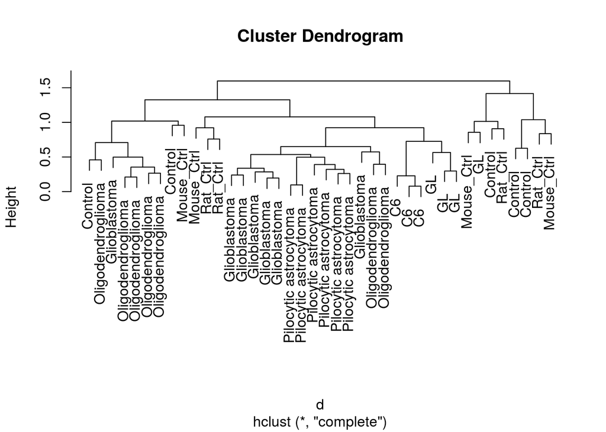

```r
clust(G_DE, Rat_DE, Mouse_DE, fun = function(M) as.dist(1-cor(M, method = "spearman")))
```

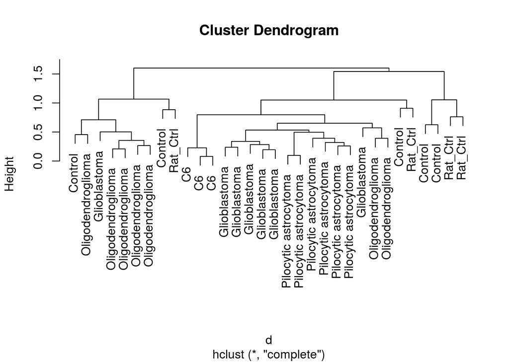

```r
clust(G_DE, Rat_DE, fun = function(M) as.dist(1-cor(M, method = "spearman")))
```

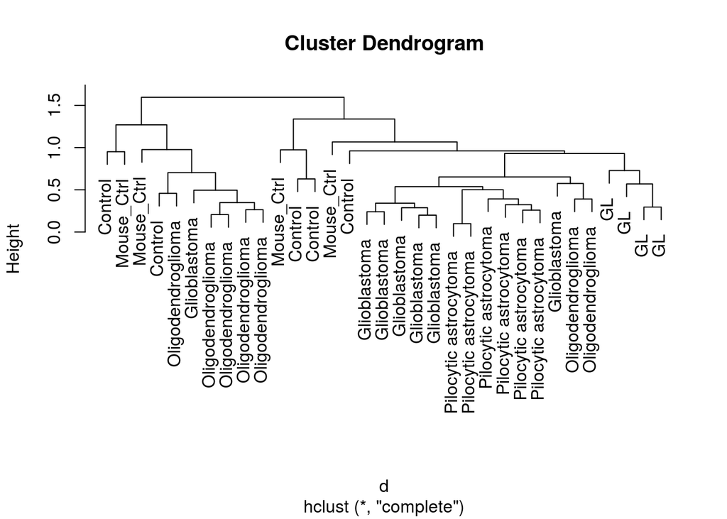

```r
clust(G_DE, Mouse_DE, fun = function(M) as.dist(1-cor(M, method = "spearman")))
```

### With Verhaak data

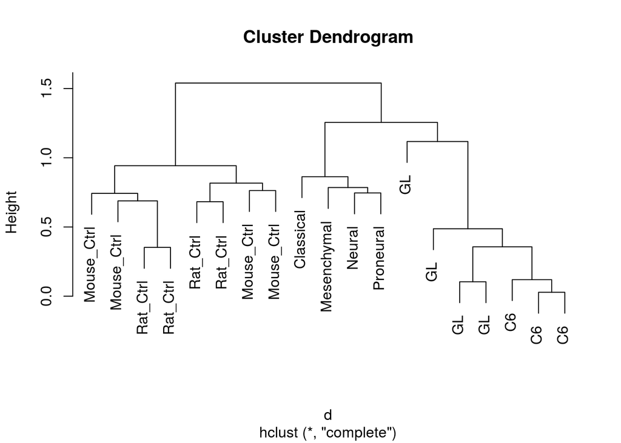

```r
clust(V_ce, med_norm(Rat), med_norm(Mouse), fun = function(M) as.dist(1-cor(M)), method = "complete")
```

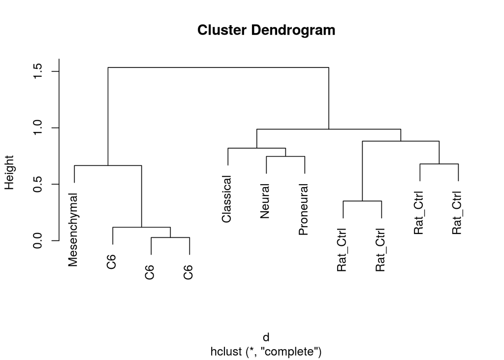

```r
clust(V_ce, med_norm(Rat), fun = function(M) as.dist(1-cor(M)), method = "complete")
```

while mouse tumour model clusters separate to all human glioblastoma subclasses:

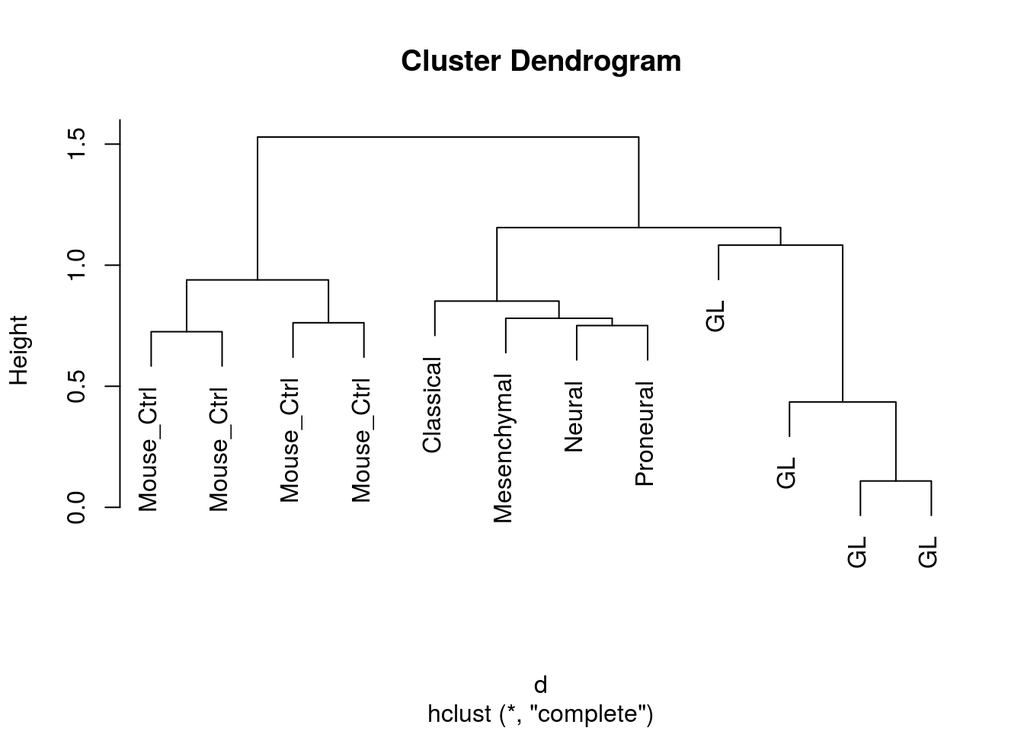

```r
clust(V_ce, med_norm(Mouse), fun = function(M) as.dist(1-cor(M)), method = "complete")
```

However, this difference between rat and mouse tumours is not observed when using mcquitty or average methods. In these cases, both rat and mouse tumours clustered together with mesenchymal glioblastoma.

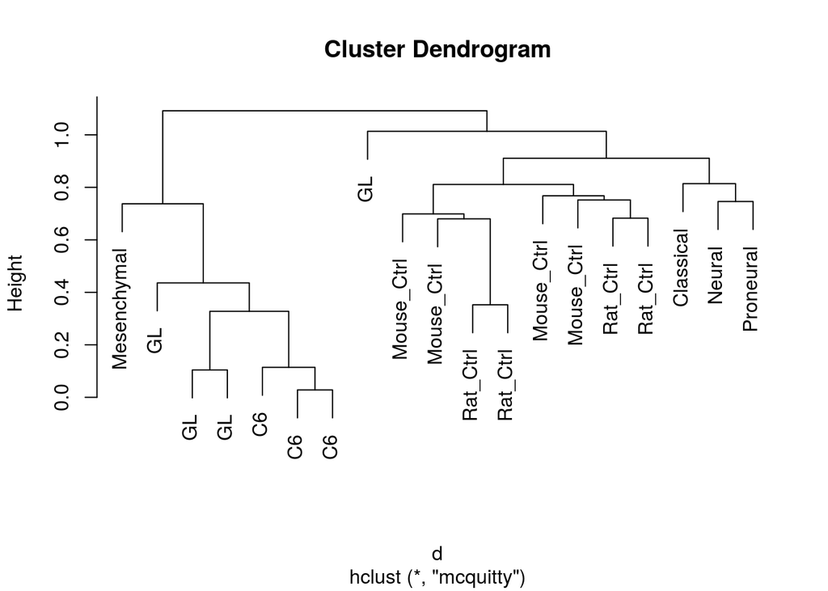

```r
clust(V_ce, med_norm(Rat), med_norm(Mouse), fun = function(M) as.dist(1-cor(M)), method = "mcquitty")
```

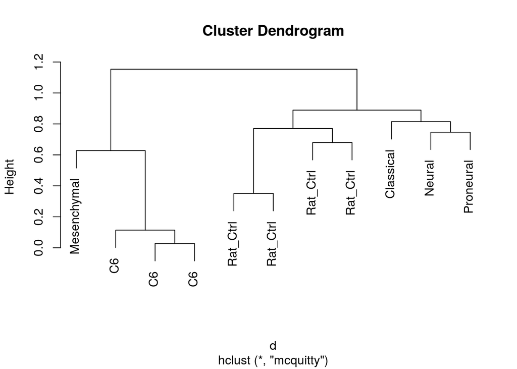

```r
clust(V_ce, med_norm(Rat), fun = function(M) as.dist(1-cor(M)), method = "mcquitty")
```

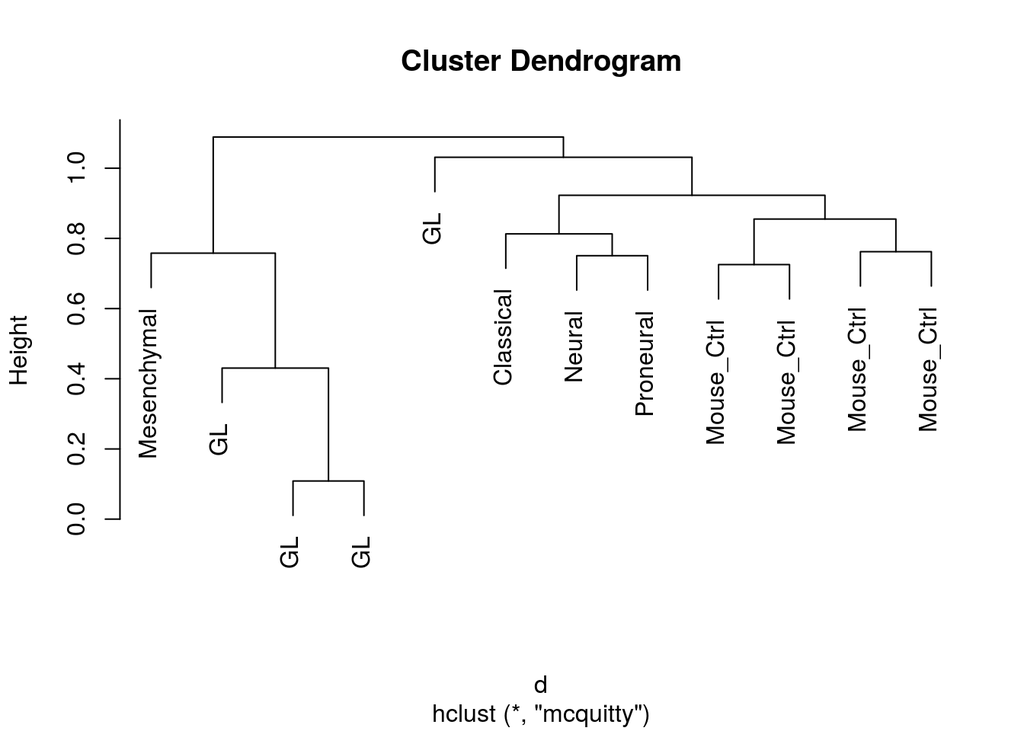

```r
clust(V_ce, med_norm(Mouse), fun = function(M) as.dist(1-cor(M)), method = "mcquitty")
```

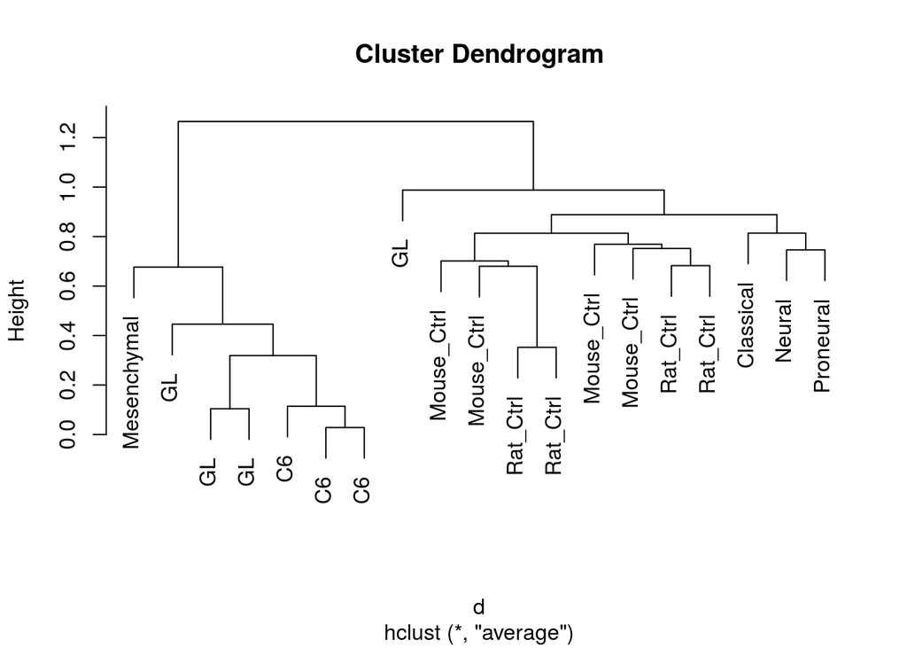

```r
clust(V_ce, med_norm(Rat), med_norm(Mouse), fun = function(M) as.dist(1-cor(M)), method = "average")
```

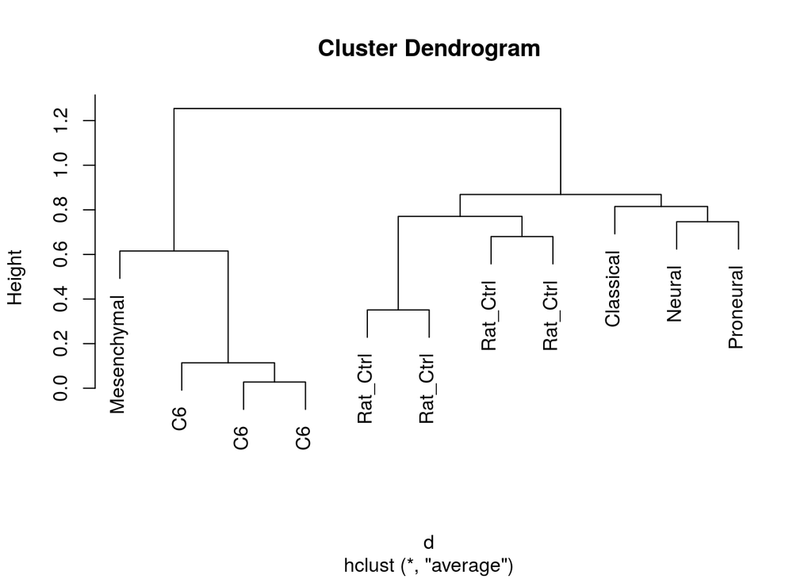

```r
clust(V_ce, med_norm(Rat), fun = function(M) as.dist(1-cor(M)), method = "average")
```

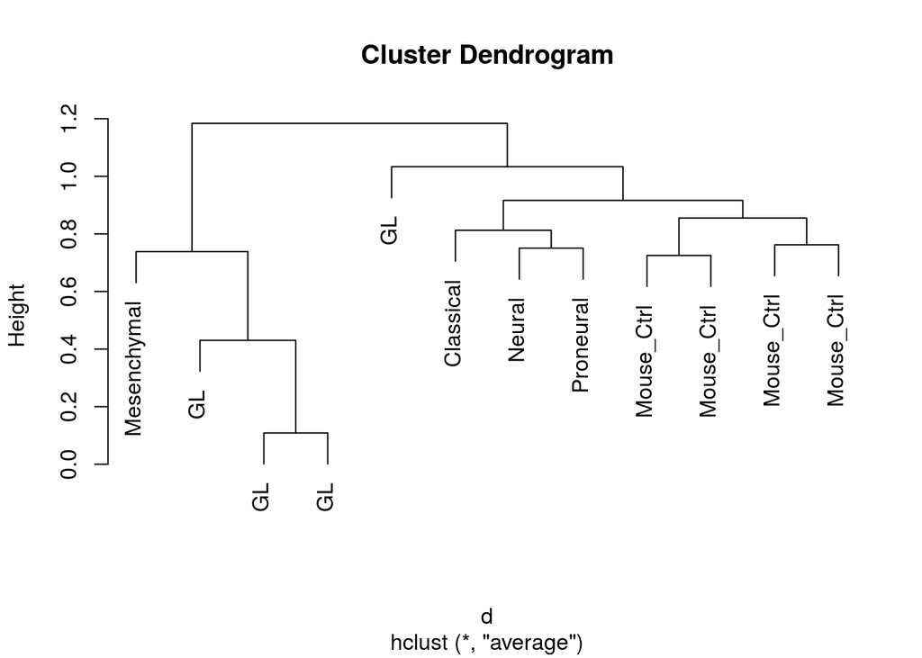

```r
clust(V_ce, med_norm(Mouse), fun = function(M) as.dist(1-cor(M)), method = "average")
```

Below is presented a heatmap for individual samples from Verhaak et al data together with the rat and mouse samples:

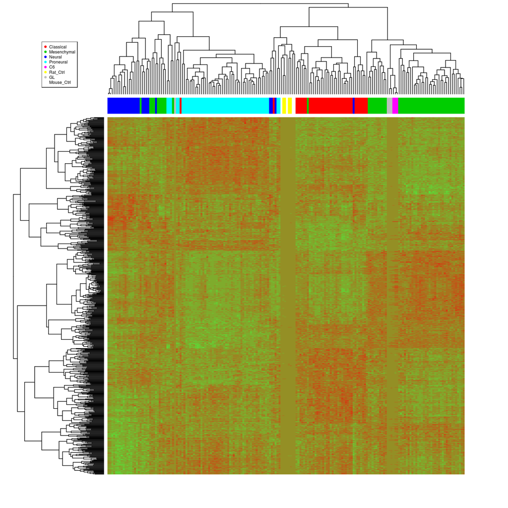

```r
heatm(V, med_norm(Rat), med_norm(Mouse), fun = function(M) as.dist(1-cor(M)), method = "complete")
```

# Conclusions

Both rat and mouse models seam to be similar to human mesenchymal glioblastoma. The rat model may better mimic mesenchymal glioblastoma than the mouse model, as observed in results of some clustering methods.